# starost

36557629 Damjan Crnković

2025-12-18

# Istraživačko pitanje: Ocjene filmova i njihova starost

#### U ovom dijelu analiziramo kako se ocjene filmova mijenjaju s obzirom na godinu izlaska. Promatramo zasbeno ocjene publike (IMDb) i ocjene kritičara (Rotten Tomatoes).

```r
oscars <- read.csv2("oscars_dataset.csv")
# glimpse(oscars)
```

#### U ovoj analizi istražujemo kako su filmovi nominirani za Oscara za najbolji film ocijenjeni s obzirom na godinu izlaska.

#### Pretvorbe tipova, uređivanje dataseta

```r
oscars <- oscars %>%
  mutate(
    IMDB.Rating = as.numeric(IMDB.Rating),
    IMDB.Votes = as.numeric(gsub(",", "", IMDB.Votes)),
    Tomatometer.Rating = as.numeric(Tomatometer.Rating),
    Audience.Rating = as.numeric(Audience.Rating),
    Award = factor(Award, levels = c("Nominee", "Winner"))
  )
```

Da bismo dobili uvid u to postoji li promjena u prosječnim ocjenama filmova kroz vrijeme, usporedit ćemo IMDb ocjene starijih i novijih filmova.

#### Side-to-side usporedba ocjena starijih i novijih filmova

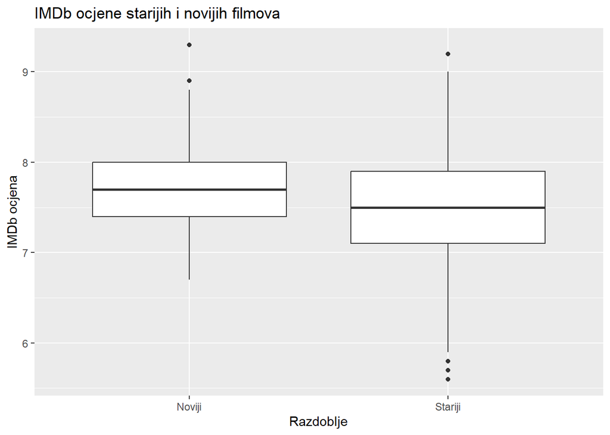

```r
oscars <- oscars %>%
  mutate(
    Period = ifelse(Year.of.Release < 1990, "Stariji", "Noviji")
  )

ggplot(oscars, aes(x = Period, y = IMDB.Rating)) +
  geom_boxplot() +
  labs(
    x = "Razdoblje",
    y = "IMDb ocjena",
    title = "IMDb ocjene starijih i novijih filmova"
  )
```

Budući da želimo statistički provjeriti postoji li značajna razlika u IMDb ocjenama između starijih i novijih filmova, primijenit ćemo neparametarski Wilcoxonov rank-sum test.

#### Wilcoxonov rank-sum test

```r
wilcox.test(
  IMDB.Rating ~ Period,
  data = oscars
)
```

```
##
##  Wilcoxon rank sum test with continuity correction
##
## data:  IMDB.Rating by Period
## W = 47342, p-value = 6.488e-08
## alternative hypothesis: true location shift is not equal to 0
```

Rezultati Wilcoxonovog testa pokazuju da je p-vrijednost vrlo mala (p < 0,001), što znači da postoji statistički značajna razlika u IMDb ocjenama između starijih i novijih filmova, pri čemu noviji filmovi imaju prosječno više ocjene.

Pogledajmo sada kako se IMDb ocjene mijenjaju kroz godine izlaska filmova.

#### Graf: IMDb ocjena filmova kroz godine

[figure not shown]

```r
ggplot(oscars, aes(x = Year.of.Release, y = IMDB.Rating)) +
  geom_point(alpha = 0.6) +
  geom_smooth(method = "lm", se = FALSE) +
  labs(
    x = "Godina izlaska",
    y = "IMDb ocjena",
    title = "Odnos godine izlaska i IMDb ocjene"
  )
```

S grafa je vidljivo da regresijski pravac ima blagi pozitivan nagib, što upućuje na to da IMDb ocjene filmova kroz vrijeme pokazuju tendenciju blagog porasta. Međutim, raspršenost podataka oko regresijske linije je velika, pa je vidljivo da je taj trend slab i da godina izlaska objašnjava samo mali dio varijabilnosti IMDb ocjena.  
Kako bi provjerili je li ovaj porast ocjena s vremenom statistički značajan, izračunat ćemo Pearsonov koeficijent korelacije između godine izlaska i IMDb ocjena.

#### Određivanje Pearsonovog koeficijenta korelacije (jačine i smjera linearne povezanosti)

```r
cor.test(
  oscars$Year.of.Release,
  oscars$IMDB.Rating,
  use = "complete.obs"
)
```

```
##
##  Pearson's product-moment correlation
##
## data:  oscars$Year.of.Release and oscars$IMDB.Rating
## t = 8.3363, df = 569, p-value = 5.783e-16
## alternative hypothesis: true correlation is not equal to 0
## 95 percent confidence interval:
##  0.2547525 0.4011050
## sample estimates:
##       cor
## 0.3299097
```

Pearsonov koeficijent korelacije između godine izlaska i IMDb ocjena iznosi 0,33, što indicira umjerenu pozitivnu linearnu povezanost. Budući da je p-vrijednost gotovo zanemariva, veza je statistički značajna. Međutim, iako trend pokazuje da noviji filmovi imaju blago više ocjene, godina izlaska objašnjava samo mali dio varijabilnosti ocjena.  
Da bismo bolje razumjeli kako godina izlaska utječe na IMDb ocjene i mogli predviđati ocjene filmova, koristit ćemo linearnu regresiju s ocjenom kao zavisnom varijablom i godinom izlaska kao neovisnom.

#### Linearna regresija - IMDb

```r
model <- lm(
  IMDB.Rating ~ Year.of.Release,
  data = oscars
)

summary(model)
```

```
##
## Call:
## lm(formula = IMDB.Rating ~ Year.of.Release, data = oscars)
##
## Residuals:
##      Min       1Q   Median       3Q      Max
## -1.68474 -0.35157  0.00511  0.36096  1.63815
##
## Coefficients:
##                   Estimate Std. Error t value Pr(>|t|)
## (Intercept)     -4.8580725  1.4910503  -3.258  0.00119 **
## Year.of.Release  0.0062981  0.0007555   8.336 5.78e-16 ***
## ---
## Signif. codes:  0 '***' 0.001 '**' 0.01 '*' 0.05 '.' 0.1 ' ' 1
##
## Residual standard error: 0.5288 on 569 degrees of freedom
## Multiple R-squared:  0.1088, Adjusted R-squared:  0.1073
## F-statistic: 69.49 on 1 and 569 DF,  p-value: 5.783e-16
```

Napravimo sada sličnu analizu gdje ćemo kao ocjenu uzeti ocjenu kritičara, odnosno Rotten Tomatoes rating.

#### Rotten Tomatoes i starost filma

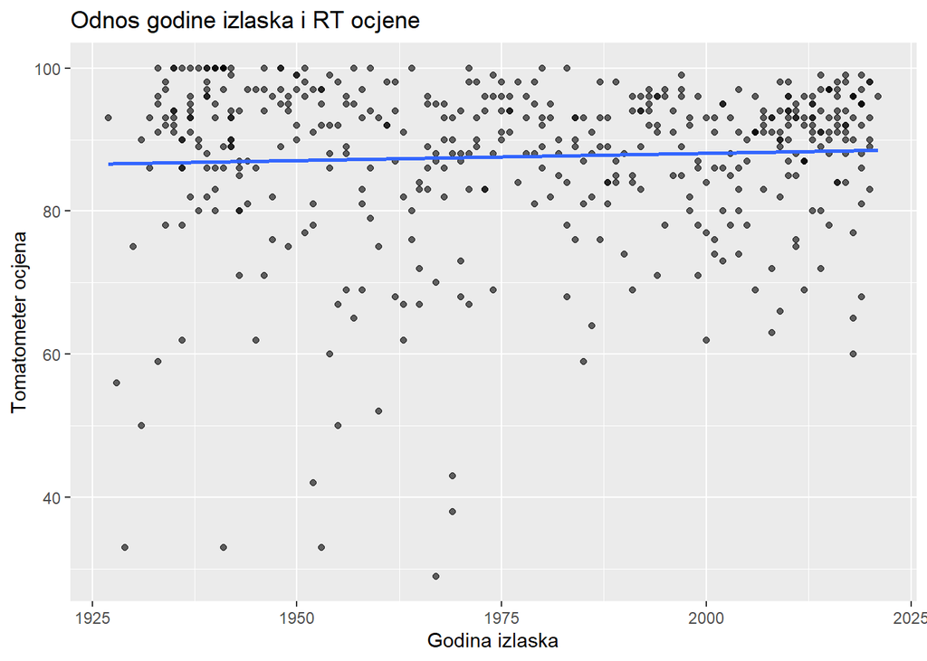

```r
ggplot(oscars, aes(x = Year.of.Release, y = Tomatometer.Rating)) +
  geom_point(alpha = 0.6) +
  geom_smooth(method = "lm", se = FALSE) +
  labs(
    x = "Godina izlaska",
    y = "Tomatometer ocjena",
    title = "Odnos godine izlaska i RT ocjene"
  )
```

Regresijski pravac u ovom slučaju ima još manji nagib, no još uvijek ima pozitivan koeficijent smjera. Raspršenost podataka ponovno je velika (ponovno slab trend), stoga izračunajmo i za ovaj set podataka Pearsonov koeficijent korelacije.

```r
cor.test(
  oscars$Year.of.Release,
  oscars$Tomatometer.Rating,
  use = "complete.obs"
)
```

```
##
##  Pearson's product-moment correlation
##
## data:  oscars$Year.of.Release and oscars$Tomatometer.Rating
## t = 1.0749, df = 457, p-value = 0.283
## alternative hypothesis: true correlation is not equal to 0
## 95 percent confidence interval:
##  -0.04149945  0.14109647
## sample estimates:
##        cor
## 0.05021814
```

Pearsonov koeficijent korelacije između godine izlaska i ocjena kritičara (Tomatometer) iznosi 0,05, što ukazuje na vrlo slab trend. P-vrijednost je 0,283, što znači da veza nije statistički značajna. Drugim riječima, **ocjene kritičara ne pokazuju pouzdan trend rasta ili pada s vremenom**.

#### Linearna regresija - Rotten Tomatoes

```r
model <- lm(Tomatometer.Rating ~ Year.of.Release, data = oscars)
summary(model)
```

```
##
## Call:
## lm(formula = Tomatometer.Rating ~ Year.of.Release, data = oscars)
##
## Residuals:
##     Min      1Q  Median      3Q     Max
## -58.427  -3.897   3.079   7.546  13.262
##
## Coefficients:
##                 Estimate Std. Error t value Pr(>|t|)
## (Intercept)     47.55938   37.29628   1.275    0.203
## Year.of.Release  0.02027    0.01886   1.075    0.283
##
## Residual standard error: 11.53 on 457 degrees of freedom
##   (112 observations deleted due to missingness)
## Multiple R-squared:  0.002522,   Adjusted R-squared:  0.0003392
## F-statistic: 1.155 on 1 and 457 DF,  p-value: 0.283
```

Linearni model pokazuje da postoji gotovo zanemariva pozitivna veza između godine izlaska i ocjena kritičara (nagib = 0,02), koja nije statistički značajna (p = 0,283) i objašnjava manje od 1% varijabilnosti ocjena.

#### Broj IMDb glasova i starost filma

[figure not shown]

```r
ggplot(oscars, aes(x = Year.of.Release, y = IMDB.Votes)) +
  geom_point(alpha = 0.6) +
  geom_smooth(method = "lm", se = FALSE) +
  labs(
    x = "Godina izlaska",
    y = "broj IMDb glasova",
    title = "Odnos godine izlaska i broja IMDb glasova"
  )
```

#### Isti postupak, uz log(IMDB.Votes)

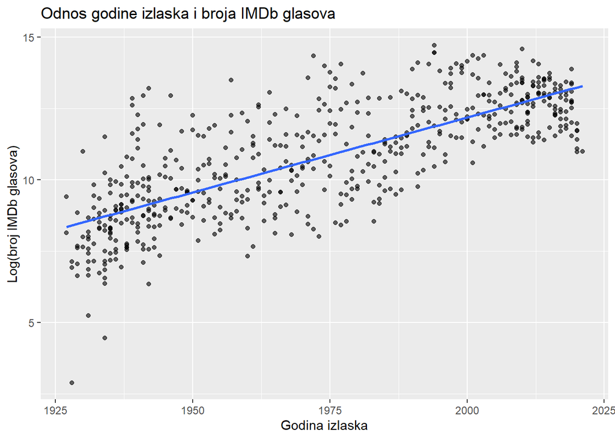

```r
ggplot(oscars, aes(x = Year.of.Release, y = log(IMDB.Votes))) +
  geom_point(alpha = 0.6) +
  geom_smooth(method = "lm", se = FALSE) +
  labs(
    x = "Godina izlaska",
    y = "Log(broj IMDb glasova)",
    title = "Odnos godine izlaska i broja IMDb glasova"
  )
```

#### Korelacija glasova i godine izlaska filma

```r
cor.test(
  oscars$Year.of.Release,
  log(oscars$IMDB.Votes),
  use = "complete.obs"
)
```

```
##
##  Pearson's product-moment correlation
##
## data:  oscars$Year.of.Release and log(oscars$IMDB.Votes)
## t = 27.999, df = 569, p-value < 2.2e-16
## alternative hypothesis: true correlation is not equal to 0
## 95 percent confidence interval:
##  0.7243963 0.7936847
## sample estimates:
##       cor
## 0.7612044
```